# Alaska

NDVI analysis {remotePARTS}

Clay Morrow

2022-06-29

# Introduction

This vignette will demonstrate the main functionality of `remotePARTS` by working through a real remote sensing data set. The example follows the more-detailed development of the methods in Ives et al. (2021, Remote Sensing of Environment, https://doi.org/10.1016/j.rse.2021.112678).

First, install/update `remotePARTS` from github if needed:

```
devtools::install_github("morrowcj/remotePARTS")
```

Then, ensure that the package is loaded into your library:

```r
library(remotePARTS)
```

This vignette will use `dplyr` and `ggplot2` for visualizing the data:

```r
library(dplyr)
##
## Attaching package: 'dplyr'
## The following objects are masked from 'package:stats':
##
##     filter, lag
## The following objects are masked from 'package:base':
##
##     intersect, setdiff, setequal, union
library(ggplot2)
```

# Alaska datasets

`remotePARTS` ships with one spatial data object. This dataset contains NDVI values derived from NASA’s MODIS satellite for the US State of Alaska. The first object, `ndvi_AK10000`, due to package size limitations, this dataset is a random sampling of 10,000 pixels from the full Alaska dataset. It is important to note, though that `remotePARTS` can handle the full map (and much larger maps).

For this vignette, we well also create a smaller 3000 pixel subsample `ndvi_AK3000` for demonstrative purposes:

```r
data("ndvi_AK10000")
ndvi_AK3000 <- ndvi_AK10000[seq_len(3000),] # first 3000 pixels from the random 10K
```

`ndvi_AK10000` is a `data.frame` with 37 columns. `lng` and `lat` are longitude and latitude, respectively. `AR_coef` and `CLS_coef` are pre-calculated coefficient estimates of the time trends in ndvi from pixel-level time series analyses via AR REML and conditional least squares, respectively. These coefficient estimates have been standardized by the mean ndvi value for the pixel over that time period. `land` is a factor representing land-cover classes, The remaining 32 columns, of the form `ndviYYYY`, contain the NDVI values from 1982 to 2013. These data sets already have rare land classes, that occur in less than 2% of pixels, removed. Additionally, both sets have no missing data. `remotePARTS` can **not** handle any missing data. It is essential that **all** missing data are removed prior to conducting any analyses.

```r
str(ndvi_AK10000)
## 'data.frame':    10000 obs. of  37 variables:
##  $ lng     : num  -151 -145 -144 -163 -145 ...
##  $ lat     : num  63.3 64.7 62.7 67.7 65.8 ...
##  $ AR_coef : num  0.01071 0.003586 0.002488 0.000373 0.002505 ...
##  $ CLS_coef: num  0.00529 0.001537 0.002276 0.000476 0.001514 ...
##  $ land    : Factor w/ 10 levels "Evergr needle",..: 6 7 7 6 7 7 6 6 7 7 ...
##  $ ndvi1982: num  1.88 7.68 8.46 6.85 10.25 ...
##  $ ndvi1983: num  1.74 8.14 7.99 6.97 10.35 ...
##  $ ndvi1984: num  1.96 8.47 8.04 6.67 10.29 ...
##  $ ndvi1985: num  1.74 7.72 7.96 6.9 10.02 ...
##  $ ndvi1986: num  1.92 8.31 8.64 6.43 10.39 ...
##  $ ndvi1987: num  2.04 8.89 8.4 7 10.47 ...
##  $ ndvi1988: num  2.13 8.5 8.32 7.12 10.05 ...
##  $ ndvi1989: num  1.93 8.99 8.79 6.24 10.16 ...
##  $ ndvi1990: num  1.73 8.66 8.45 7.46 10.31 ...
##  $ ndvi1991: num  1.99 8.74 8.34 6.86 10.28 ...
##  $ ndvi1992: num  1.74 7.99 7.94 6.53 9.77 ...
##  $ ndvi1993: num  1.98 8.62 7.93 6.97 10.35 ...
##  $ ndvi1994: num  2.04 8.59 8.26 7.15 10.25 ...
##  $ ndvi1995: num  1.9 8.1 8.55 7.08 10.18 ...
##  $ ndvi1996: num  2.09 8.61 8.23 7.08 10.33 ...
##  $ ndvi1997: num  1.81 8.77 8.99 7.24 10.23 ...
##  $ ndvi1998: num  1.95 7.9 8.57 7.45 9.99 ...
##  $ ndvi1999: num  1.75 8.14 8.61 6.75 10.04 ...
##  $ ndvi2000: num  1.71 7.5 8.37 6.7 9.92 ...
##  $ ndvi2001: num  1.57 7.76 8.29 6.66 9.69 ...
##  $ ndvi2002: num  1.72 7.83 8.62 7.09 9.76 ...
##  $ ndvi2003: num  1.95 7.94 8.35 6.87 9.76 ...
##  $ ndvi2004: num  2.2 8.37 8.83 7.3 11.74 ...
##  $ ndvi2005: num  2.18 8.45 8.63 7.18 11.62 ...
##  $ ndvi2006: num  2.06 8.32 8.36 6.74 11.59 ...
##  $ ndvi2007: num  2.39 8.53 8.63 7.47 11.91 ...
##  $ ndvi2008: num  2.36 8.6 8.41 7 11.8 ...
##  $ ndvi2009: num  2.35 10.02 9.27 6.59 11.62 ...
##  $ ndvi2010: num  2.95 11.09 9.26 7.09 11.46 ...
##  $ ndvi2011: num  2.5 8.9 8.94 7.05 12.15 ...
##  $ ndvi2012: num  2.71 8.71 8.39 6.21 10.97 ...
##  $ ndvi2013: num  2.54 9 8.95 6.93 10.38 ...
```

For this demonstration, we are interested in asking the following questions using these data: “Is NDVI in Alaska increasing over time?”; “Are Alaska’s NDVI time trends associated with land-cover classes?”; and “Do Alaska’s NDVI time trends differ with latitude?”

The figure below shows a temporal cross-section of these data for 1982, 1998, and 2013.

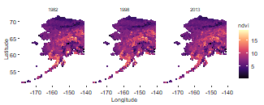

```r
reshape2::melt(ndvi_AK10000, measure = c("ndvi1982", "ndvi1998", "ndvi2013")) %>%
  ggplot(aes(x = lng, y = lat, col = value )) +
  geom_point(size = .1) +
  labs(col = "ndvi") +
  facet_wrap(~ gsub("ndvi", "", variable), ncol = 3) +
  scale_color_viridis_c(option = "magma") +
  labs(x = "Longitude", y = "Latitude")
```

The following figure shows how Alaska’s three primary land-cover classes are distributed.

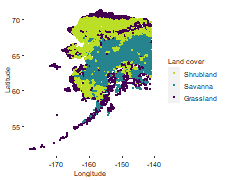

```r
ndvi_AK10000 %>%
ggplot(aes(x = lng, y = lat, col = land)) +
  geom_point(size = .1) +
  scale_color_viridis_d(direction = -1, end = .9) +
  labs(y = "Latitude", x = "Longitude", col = "Land cover", fill = "Land cover")
```

Use `help("ndvi_AK)` to see documentation for these datasets.

# Model

When using `remotePARTS`, the data are assumed to follow the general stochastic process of the form

$$y(t) = X(t)\beta +
\varepsilon(t)$$
where

- $y(t)$ is a response variable of interest at time $t$
- $\beta$ is a vector of coefficients for the predictor variables $X(t)$ on $y(t)$
- $\varepsilon(t)$ is an temporal autoregressive process: $\varepsilon(t) = \rho \varepsilon(t - 1) + \delta(t)$
- at any time step, $\delta(t)$ is spatially autocorrelated according to covariance matrix $\Sigma$: $\delta(t) \sim N(0, \Sigma)$
- there is no temporal dependence in $\delta(t)$ (i.e., $\delta(t_i)$ is independent of $\delta(t_j)$ except when $t_i$ = $t_j$)

# Time-series analysis

The first step in a typical `remotePARTS` workflow is to obtain pixel-level estimates of time-series coefficients. In our example, we are interested in estimating the time trends in NDVI for each pixel $i$, represented by $\beta_1$ in the regression model

$$y_i(t) = \beta_0 + \beta_1 t +
\varepsilon_i(t)$$

where the random errors $\varepsilon_i(t)$ follow an AR(1) process:

$$\varepsilon_i(t) = b\varepsilon_i(t - 1)
+ \delta_i(t)$$
$$\delta_i(t) \sim N(0
, \sigma)$$

We will use `fitAR_map()` to estimate $\beta_1$, which fits pixel-level AR(1) models to a map of pixels and estimates coefficients using restricted maximum likelihood (REML). To do so, we must extract only our NDVI columns as the matrix `Y`. We’ll do this by matching all column names containing “ndvi” and slicing the data.frame:

```r
ndvi.cols <- grep("ndvi", names(ndvi_AK3000), value = TRUE)
Y <- as.matrix(ndvi_AK3000[, ndvi.cols])
```

We also need a 2-column coordinate matrix `coords`:

```r
coords <- as.matrix(ndvi_AK3000[, c("lng", "lat")])
```

`Y` and `coords` are then passed to `fitAR_map()` with default settings:

```r
ARfit <- fitAR_map(Y = Y, coords = coords)
```

Coefficient estimates can be obtained from `ARfit` with `coefficients()`. The first column is the estimate of $\beta_0$, $\hat{\beta_0}$, and the second is $\hat{\beta_1}$.

```r
head(coefficients(ARfit))
##      (Intercept)            t
## [1,]    1.703446  0.021923615
## [2,]    7.980618  0.030464243
## [3,]    8.146784  0.021130056
## [4,]    6.883592  0.002582853
## [5,]   10.081968  0.026466877
## [6,]    7.628119 -0.010395964
```

These time-series analyses calculate the time trend in the raw NDVI data. In most situations it makes sense to ask if there are time trends in the relative NDVI values, that is, changes in NDVI relative to the mean value of NDVI in a pixel. Scaling the trend in NDVI relative to the mean gives assessments of the **proportional** change in NDVI. These trends in the proportional NDVI are calculated be dividing $\hat{\beta_1}$ by the mean. The values of the trend coefficients are contained in `ARfit$coefficients`, and since the coefficients for the trend are in the column of the coefficients matrix named `t`, the scaling is performed as

```r
ARfit$coefficients[, "t"] <- ARfit$coefficients[,"t"]/rowMeans(ndvi_AK3000[, ndvi.cols])
ndvi_AK3000$AR_coef <- coefficients(ARfit)[, "t"] # save time trend coefficient
```

These scaled values of the time trend are then stored in the `ndvi_AK3000` data frame.

Below is an image of the estimated coefficients (pre-calculated and scaled) for the full `ndvi_AK10000`. From this, it appears that northern latitudes may be greening faster than more southern latitudes.

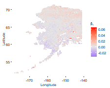

```r
ndvi_AK10000 %>%
  ggplot(aes(x = lng, y = lat, col = AR_coef)) +
  geom_point(size = .1) +
  scale_color_gradient2(high = "red", low = "blue",
                        mid = "grey90", midpoint = 0) +
  guides(fill = "none") +
  labs(y = "Latitude", x = "Longitude", col = expression(beta[1]))
```

`fitAR_map` and its conditional least-squares counterpart, `fitCLS_map`, are wrappers for the functions `fitAR` and `fitCLS` which conduct individual time series analysis. If the user wants, these can be applied on a pixel-by-pixel basis to the data to allow greater flexibility. Both AR REML and CLS methods account for temporal autocorrelation in the time series. See function documentation for more details (i.e., `?fitAR_map()`).

# Spatial relationships

Now that we’ve reduced the temporal component of each time series to a single value (i.e., estimates of $\beta_1$) while accounting for temporal autocorrelation, we can focus on the spatial component of our problem.

## Distance

The first step is to calculate the distances among pixels as a distance matrix `D`. Here, we’ll calculate relative distances with `distm_scaled()` from our coordinate matrix.

```r
D <- distm_scaled(coords)
```

`distm_scaled()` scales distances across the spatial domain so that the greatest distance between two pixels is 1. Note that because `distm_scaled()` uses `geosphere::distm()`, it treats coordinates as degrees longitude and latitude on a sphere and calculates distances accordingly.

## Covariance

Next, we need to estimate the expected correlation between the random errors of our spatial response variable (estimates of $\beta_1$) based on their distances. To do so, we need a spatial covariance function. In this example, we will use an exponential covariance function to estimate correlations: $V = \exp\big(\frac{-D}{r}\big)$ where $r$ is a parameter that dictates the range of spatial autocorrelation. The function `covar_exp()` corresponds to this covariance function.

`V` represents the correlation among points if all variation is accounted for. However, it is safest to assume that there is some additional source of unexplained and unmeasured variance (a nugget $\eta$). Therefore, we assume that the covariance structure among pixels is given by $\Sigma = \eta I + (1-\eta)V$ where $I$ is the identity matrix.

If we know the range parameter $r$, we can calculate `V` from `D` with `covar_exp()`:

```r
r <- 0.1
V <- covar_exp(D, r)
```

And we could add a known nugget to `V` to obtain `Sigma`:

```r
nugget <- 0.2
I <- diag(nrow(V)) # identity matrix
Sigma <- nugget*I + (1-nugget)*V
```

See `?covar_exp()` for a description of the covariance functions provided by `remotePARTS` and for more information regarding their use.

# GLS: 3000-pixel subset

To test spatial hypotheses with `remotePARTS`, we use a generalized least-squares regression model (GLS):

$$\theta = X\alpha_{gls} + \gamma$$
where

- $\theta$ is a vector of response values
- $\alpha_{gls}$ is a vector of the effects of predictor variables $X$ on $\theta$
- the error term $\gamma$ is spatially autocorrelated according to $\Sigma_\gamma$: $\gamma \sim N(0, \Sigma_\gamma)$

$\theta$ will usually be a regression parameter. For example, if we’re interested in understanding trends in NDVI over time, we would use the pixel-level regression coefficient for the effect of time on NDVI (i.e., $\theta = \hat\beta$)

## Known parameters

If the parameters that govern the spatial autocorrelation $\Sigma_\gamma$ are known, a GLS can be fit with `fitGLS()`. Here, we will fit the GLS by providing (i) a model formula, (ii) a data source, (iii) our `V` matrix, which was pre-calculated with a spatial parameter $r = 0.1$ and (iv) a nugget of $\eta = 0.2$.

The specific task in this examples is to estimate the effect of land-cover class on our time trend. Because `land` is a factor, we’ll also specify a no-intercept model.

Note that the GLS fitting process requires an inversion of `V`. This means that even with only the 3000-pixel subset, it will take a few minutes to finish the computations on most computers.

```r
GLS.0 <- fitGLS(formula = AR_coef ~ 0 + land, data = ndvi_AK3000, V = V, nugget = nugget)
```

Note also that `fitGLS` adds the nugget to `V` internally. If we wanted to do this ourselves, we could pass the covariance matrix `Sigma` which already contains a nugget component and then set the `nugget` argument of `fitGLS` to 0:

```r
fitGLS(formula = AR_coef ~ 0 + land, data = ndvi_AK3000, V = Sigma, nugget = 0) # equivalent
```

The estimates for our land class effects can be extracted with `coefficients()`.

```r
coefficients(GLS.0)
## landShrubland   landSavanna landGrassland
##  0.0008646565  0.0002554862  0.0011294576
```

The full model fit is given by

```r
GLS.0
##
## Call:
## fitGLS(formula = AR_coef ~ 0 + land, data = ndvi_AK3000, V = V,
##     nugget = nugget)
##
## t-tests:
##                     Est t.stat pval.t
## landShrubland 0.0008647 0.5065 0.6126
## landSavanna   0.0002555 0.1493 0.8813
## landGrassland 0.0011295 0.6648 0.5062
##
## F-test:
##                model df_F    SSE       MSE logLik Fstat  pval_F
## 1 AR_coef ~ 0 + land    2 0.1128 3.764e-05  12808 4.461 0.01163
## 2        AR_coef ~ 1 2997 0.1131 3.775e-05  12802    NA      NA
```

Note that, although none of the three land-cover classes shows a statistically significant time trend in (proportional) NDVI, the F-test shows that there is a statistically significant difference among land-cover classes, because the model including land-cover classes gives a statistically significantly better fit to the data than the intercept-only model.

## Parameter estimation

In practice, we rarely know the values of the parameters that govern spatial autocorrelation (e.g., the range and nugget) in advance. Therefore, these parameters will need to be estimated for most data.

### Spatial parameters

The spatial parameters of a covariance function (e.g., `covar_exp`) can be estimated from residuals of pixel-level time-series models (see Ives et al. RSE, 2021). Although we conducted the time-series analyses as though each pixel was independent (with `fitAR_map()`), they are, in fact, dependent. Specifically, the correlation of the residuals from the pixel-level analyses is roughly proportional to the spatial autocorrelation of the residuals of the spatial model, $\gamma$, if all of the variation in $\gamma$ is due to the spatiotemporal variation produced by $\varepsilon_i(t)$. Therefore, we can estimate the range parameter for **V** as $V_{ij} \approx \text{cor}\big(\varepsilon_i(t), \varepsilon_j(t)\big)$

The function `fitCor()` performs the estimation of spatial parameters. We will pass to this function (i) the time-series residuals for our map, extracted from the time-series analysis output object with `residuals()`, (ii) the coordinate matrix `coords`, (iii) the covariance function `covar_exp()`, and (iv) a list specifying that we should start the search for the optimal range parameter at 0.1. For this example, we will also specify `fit.n = 3000`, which ensures that all pixels are used to estimate spatial parameters.

```r
corfit <- fitCor(resids = residuals(ARfit), coords = coords,
                covar_FUN = "covar_exp", start = list(range = 0.1),
                fit.n = 3000)
(range.opt = corfit$spcor)
##     range
## 0.1083729
```

By default, `fitCor()` uses `distm_scaled()` to calculate distances from the coordinate matrix, but any function that returns a distance matrix can be specified with the `distm_FUN` argument. It is important to scale the parameter values appropriately, accounting for your distances. For example, if we instead use `distm_km()` to calculate distance in km instead of relative distances, we would need to scale our starting range parameter by the maximum distance in km of our map:

```r
max.dist <- max(distm_km(coords))
corfit.km <- fitCor(resids = residuals(ARfit), coords = coords,
                   covar_FUN = "covar_exp", start = list(range = max.dist*0.1),
                   distm_FUN = "distm_km", fit.n = 3000)
```

Note that, depending on the covariance function used, not all parameters will need scaling. For example, `covar_exppow()` is an exponential-power covariance function and takes a range and shape parameter, but only the range parameter should scale with distance. See `?fitCor()` for more details.

After we’ve obtained our range parameter estimate, we can use it to re-calculate the `V` matrix:

```r
V.opt <- covar_exp(D, range.opt)
```

### Nugget

Similar to finding the optimal spatial parameters, the nugget can be estimated by selecting a nugget that maximizes the likelihood of the GLS given the data. `fitGLS()` will find this maximum-likelihood nugget when `nugget = NA` is specified. Note that this type of optimization requires fitting multiple GLS models, which means it will be much slower than our call to `fitGLS()` with a known nugget.

In addition to our original arguments, we’ll also explicitly set `no.F = FALSE` so that F-tests are calculated. For the F-tests, the default reduced model is the intercept-only model, although it is also possible to specify alternative reduced models as a formula in the `formula0` option.

```r
GLS.opt <- fitGLS(formula = AR_coef ~ 0 + land, data = ndvi_AK3000, V = V.opt, nugget = NA,
                 no.F = FALSE)
(nug.opt = GLS.opt$nugget)
## [1] 0.1342314
coefficients(GLS.opt)
## landShrubland   landSavanna landGrassland
##  0.0009201230  0.0003899361  0.0011467324
```

Let’s compare our GLS from earlier with this one with optimized parameters:

```r
rbind(GLS.0 = c(range = r, nugget = GLS.0$nugget, logLik = GLS.0$logLik, MSE = GLS.0$MSE),
      GLS.opt = c(range = range.opt, nugget = GLS.opt$nugget, logLik = GLS.opt$logLik, MSE = GLS.opt$MSE))
##             range    nugget   logLik          MSE
## GLS.0   0.1000000 0.2000000 12807.91 3.763878e-05
## GLS.opt 0.1083729 0.1342314 12809.46 5.003165e-05
```

Note that in this example, `logLik` for `GLS.opt` is not functionally different than `logLik` for `GLS.0`. This indicates that using the values of `range` = 0.1 and `nugget` = 0.2 gives a similar likelihood than the optimal model when `range` is constrained to be the value calculated from `covar_exp()`, `GLS.opt`.

### Simultaneous parameter estimation

It is also possible to simultaneously estimate spatial parameters and the nugget without using the time-series residuals. This is done by finding the set of parameters describing spatial autocorrelation (e.g., `range` and `nugget`) that maximizes the likelihood of a GLS given the data. This task is computationally slower than optimizing `nugget` alone with `fitGLS()` and therefore will take some time to run.

```r
fitopt <- fitGLS_opt(formula = AR_coef ~ 0 + land, data = ndvi_AK3000,
                       coords = ndvi_AK3000[, c("lng", "lat")],
                       covar_FUN = "covar_exp",
                       start = c(range = .1, nugget = .2))
fitopt$opt$par
##      range     nugget
## 0.03660171 0.26859993
fitopt$GLS$logLik
## [1] 13276.15
fitopt$GLS$MSE
## [1] 1.720775e-05
```

Note that, because `fitGLS_opt()` does not require time series residuals, it is possible to use `fitGLS_opt()` for statistical problems involving only spatial variables. In other words, rather than $\theta$ being a limited to a time trend, it can be a purely spatial variable as well.

When time-series residuals are available, we recommend that you estimate spatial parameters with `fitCor()` and `fitGLS()`, rather than `fitGLS_opt()`. In simulation studies, using `fitCor()` with `fitGLS()` often has better statistical performance than using `fitGLS_opt()`. See `?fitGLS_opt()` for more information about this function and its use.

# Hypothesis testing

The purpose of the tools provided by `remotePARTS` is to test map-level hypotheses about spatiotemporal data sets. In this example, we will test 3 hypotheses using 3 different GLS models. Note that these hypothesis are framed as regression-style problems; indeed, `fitGLS()` is essentially regression with spatially autocorrelated random errors.

## Intercept-only model

If we want to test the hypothesis that “there was a trend in Alaska NDVI Alaska from 1982-2013”, we can regress the AR coefficient on an intercept-only GLS model:

```r
(GLS.int <- fitGLS(AR_coef ~ 1, data = ndvi_AK3000, V = V.opt, nugget = nug.opt, no.F = TRUE))
##
## Call:
## fitGLS(formula = AR_coef ~ 1, data = ndvi_AK3000, V = V.opt,
##     nugget = nug.opt, no.F = TRUE)
##
## t-tests:
##                  Est t.stat pval.t
## (Intercept) 0.000972 0.4564 0.6481
##
## Model statistics:
##      SSE       MSE logLik
## 1 0.1503 5.011e-05  12806
```

We can see from the t-test that the intercept is not statistically different from zero. In other words, there is no map-level temporal trend in NDVI across the entire data set. We have not performed an F-test, because the full model is the intercept-only model and is therefore the same as the reduced model.

## Land-cover effects

If we want to test the hypothesis that “trends in Alaskan NDVI differ by land- cover class”, we can use `GLS.opt()` from earlier:

```r
GLS.opt
##
## Call:
## fitGLS(formula = AR_coef ~ 0 + land, data = ndvi_AK3000, V = V.opt,
##     nugget = NA, no.F = FALSE)
##
## t-tests:
##                     Est t.stat pval.t
## landShrubland 0.0009201 0.4306 0.6668
## landSavanna   0.0003899 0.1822 0.8554
## landGrassland 0.0011467 0.5385 0.5903
##
## F-test:
##                model df_F    SSE       MSE logLik Fstat  pval_F
## 1 AR_coef ~ 0 + land    2 0.1499 5.003e-05  12809 3.263 0.03841
## 2        AR_coef ~ 1 2997 0.1503 5.014e-05  12805    NA      NA
```

The t-tests show that the trend in NDVI, for all land-cover classes, was not statistically different from zero, meaning that NDVI did not show a statistically significant trend in any land-cover class. The F-test (ANOVA table), however, shows that time trends in NDVI differ among the land-cover classes. The better fit of the model with land-cover classes can also be seen in the increase in the likelihood (`logLik`) compared to the intercept-only model.

## Latitude effects

Finally, to test the hypothesis that “temporal trends in NDVI differ with latitude”, we can regress the AR coefficient on latitude in our GLS model:

```r
(GLS.lat <- fitGLS(AR_coef ~ 1 + lat, data = ndvi_AK3000, V = V.opt, nugget = nug.opt,
                   no.F = FALSE))
##
## Call:
## fitGLS(formula = AR_coef ~ 1 + lat, data = ndvi_AK3000, V = V.opt,
##     nugget = nug.opt, no.F = FALSE)
##
## t-tests:
##                    Est   t.stat pval.t
## (Intercept) -8.617e-04 -0.04362 0.9652
## lat          2.986e-05  0.09337 0.9256
##
## F-test:
##               model df_F    SSE       MSE logLik    Fstat pval_F
## 1 AR_coef ~ 1 + lat    1 0.1503 5.012e-05  12806 0.008719 0.9256
## 2       AR_coef ~ 1 2998 0.1503 5.012e-05  12806       NA     NA
```

The t-tests show that temporal trends in NDVI did not differ with latitude. Note that the p-value from the F-test is equivalent to that of the t-test p-value for effect of latitude.

## Conclusions (ndvi_AK3000)

# GLS: Full dataset

Until now, we have limited our analyses to the 3000-pixel subset of Alaska, `ndvi_AK3000`. Calls to `fitGLS()` involve inverting `V`, and the computational complexity scales with $N^3$ where $N$ is the number of pixels in the map. We have used the data set `ndvi_AK3000` up to now because the computation time for the analyses is reasonable. However, 3000 pixels means dealing with distance and covariance matrices that each contain $3,000 \times 3,000 = 9,000,000$ elements. This is approaching the upper size limit for obtaining relatively fast results.

In contrast, the covariance matrix for the full `ndvi_AK10000` data set would have $10,000 \times 10,000 = 100,000,000$ elements which creates a computationally infeasible problem for a normal computer.

For these reasons, `fitGLS_paritition` may be the most useful function in the `remotePARTS` package. This function can perform the GLS analysis on the full `ndvi_AK10000` data set. In fact, `ndvi_AK10000` is quite small in comparison to many remote sensing data sets that could be analyzed with `fitGLS_partition()`.

## Partitioned GLS

`fitGLS_parition()` conducts GLS analyses on partitions of the data and then combines the results from the partitions to give overall statistical results. Specifically, this process (1) breaks the data into smaller and more manageable pieces (partitions), (2) conducts GLS on each partition, (3) calculates cross-partition statistics from pairs of partitions, and (4) summarizes the results with statistical tests that account for correlations among partitions. We will use the full `ndvi_AK10000` data set to demonstrate `fitGLS_parition()`.

```r
df = ndvi_AK10000
```

```r
pm <- sample_partitions(npix = nrow(df), partsize = 1500, npart = NA)
dim(pm)
## [1] 1500    6
```

Once we have our partition matrix, `fitGLS_parititon()` performs steps (2)-(4) of the analyses. The input is similar to `fitGLS`. For this example, we specify (i) a formula, (ii) the data as a data.frame (`df`), (iii) the partition matrix (partmat `pm`), (iv) the covariance function (`covar_FUN`), (v) a list of spatial parameters `covar.pars` including our optimized range parameter, and a `nugget`. If `nugget` is specified, this value is used for the calculations, while if `nugget` = `NA` (the default) it is estimated for each partition separately.

Note that, although the compute time is much faster than if we needed to invert the full covariance matrix `V`, this example still takes a long time to fit. Therefore, we have saved the output of this code as an R object `partGLS.ndviAK` so that you can look at its output without having to execute the function.

The model was fit with this code:

```r
partGLS_ndviAK <- fitGLS_partition(formula = AR_coef ~ 0 + land, data = df,
                                   partmat = pm, covar_FUN = "covar_exp",
                                   covar.pars = list(range = range.opt),
                                   nugget = nug.opt, ncores = 4)
```

and can be loaded with

```r
data(partGLS_ndviAK)
```

```r
partGLS_ndviAK$overall$t.test
## $p.t
##                        Est          SE    t.stat    pval.t
## landShrubland 0.0013094359 0.001899589 0.6893260 0.4906359
## landSavanna   0.0004379666 0.001902064 0.2302586 0.8178960
## landGrassland 0.0016210956 0.001894683 0.8556027 0.3922404
##
## $covar_coef
##              [,1]         [,2]         [,3]
## [1,] 3.623978e-06 3.569499e-06 3.561642e-06
## [2,] 3.566697e-06 3.633439e-06 3.537596e-06
## [3,] 3.562415e-06 3.540957e-06 3.605232e-06
```

It is **highly** recommended that users read the full documentation (`?fitGLS_parition()`) before using `fitGLS_partition` to analyze any data.

Here is the p-value for the chisqr test of the partitioned GLS

```r
partGLS_ndviAK$overall$pval.chisqr
## pval.chisqr
##       1e-06
## attr(,"rankdef.MSR")
## [1] 0
```

This again, indicates that the model which includes land cover classes better explains variation in NDVI trends than the intercept-only model. Note that the p-value is much lower than the p-value from the F-test conducted by `fitGLS()`. This is likely due to outliers in the data, which should be removed before conducting any real analysis. One simple way to filter potential trend outliers would be to remove any pixels whose time-series coefficient standard errors are unusually large (e.g., `SE > 4*mean(SE)`).

## Conclusions

Our parititoned GLS has returned the same conclusions as our standard GLS analysis. No map-level trend in NDVI was found within any of the land cover classes.

This was only one of our three hypotheses tested earlier. The remaining two can easily be tested with `fitGLS_partition()`, as they were with `fitGLS`, by changing the formula argument.